# HW Адилхан Санжар БЭК 212

Бутстрап t-статистики.

```python
np.random.seed(2004)
n_iter = 10000
confidence = 95
intensity = 1
sample_size = 20

cnt = 0

for i in range(n_iter):
    sample = np.random.standard_t(df = 3, size = 20)
    bootstrap = np.random.choice(sample, size = (10000, 20))
    mean_obs = np.mean(sample)
    std_obs = np.std(sample)
    mean_bootstrap = np.mean(bootstrap, axis = 1)
    std_bootstrap = np.std(bootstrap, axis = 1)
    stat = (mean_bootstrap - mean_obs)/std_bootstrap
    left_b = mean_obs - np.percentile(stat, (100 - confidence)/2) * std_obs
    right_b = mean_obs - np.percentile(stat, (100 + confidence)/2) * std_obs
    if (right_b <= 0) & (left_b >= 0):
        cnt += 1
    else:
        continue

cnt/n_iter
```

```
0.9251
```

Задача 3 (в). **Выводы:**

2) Для распределения Стьюдента наилучшим методом построения доверительного интервала оказался классический доверительный интервал с вероятностью 0.941.

Задача 4 (а). Тест Уэлча

$$ H0: \mu_c = \mu_v $$$$ H1: \mu_c \neq \mu_v $$

, $$ где \ \mu_c - математическое \ ожидание \ результатов \ студентов \ с \ фамилией, \ начинающейся \ на \ согласную $$

$$ \mu_v - математическое \ ожидание \ результатов \ студентов \ с \ фамилией, \ начинающейся \ на \ гласную $$

```python
import pandas as pd
import scipy.stats as stats

df = pd.read_csv("results.csv", delimiter = ";")
df.dropna(inplace = True) ## Удалили пропуски

vowels = ['А', 'Е', 'И', 'О', 'У', 'Ы', 'Э', 'Ю', 'Я']
df_v = df[df['Фамилия'].str[0].str.upper().isin(vowels)] ## гласная
df_c = df[~df['Фамилия'].str[0].str.upper().isin(vowels)] ## согласная
score_v = df_v["Балл"]
score_c = df_c["Балл"]

t_statistic, p_value = stats.ttest_ind(df_v["Балл"], df_c["Балл"], equal_var = False)
round(p_value, 3)
```

```
0.397
```

$$ p-value \ в \ данном \ тесте \ больше \ уровня \ значимости \ (0.397 > 0.05), \ следовательно, \ гипотеза \ H0 \ не \ отвергается $$

Задача 4 (б). Наивный бутстрэп

```
-3.562 1.382
```

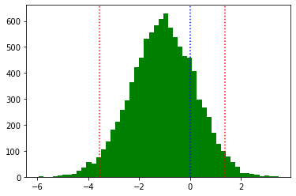

```python
np.random.seed(2004)

confidence = 95
observed_diff = np.mean(score_v) - np.mean(score_c)
n_iter = 10000
bootstrap = []

for i in range(n_bootstrap):
    bootstrap_v = np.random.choice(score_v, size = len(score_v))
    bootstrap_c = np.random.choice(score_c, size = len(score_c))
    diff = np.mean(bootstrap_v) - np.mean(bootstrap_c)
    bootstrap.append(diff)

b_left = np.percentile(bootstrap, (100 - confidence)/2)
b_right = np.percentile(bootstrap, (100 + confidence)/2)
print(round(b_left, 3), round(b_right, 3)) ## 0 входит в интервал, следовательно, H0 не отвергается.
plt.hist(bootstrap, bins = 50, color = "green")
plt.axvline(x = 0, color = "blue", linestyle = ":")
plt.axvline(x = b_left, color = "red", linestyle = ":")
plt.axvline(x = b_right, color = "red", linestyle = ":")
None
```

**Вывод: 0 входит в интервал, следовательно, нет оснований отвергать H0.**

Задача 4 (в). Бутстрэп t-статистики.

```
(-1.9313640718385687, 0, 2.136984284301288)
```

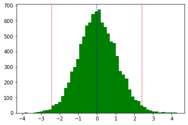

```python
np.random.seed(2004)
confidence = 95
n_iter = 10000

score_v_mean = np.mean(score_v)
score_c_mean = np.mean(score_c)
score_v_se = np.std(score_v)/np.sqrt(len(score_v))
score_c_se = np.std(score_c)/np.sqrt(len(score_c))
stats = []
for i in range(n_iter):
    bootstrap_v = np.random.choice(score_v, size = len(score_v))
    bootstrap_c = np.random.choice(score_c, size = len(score_c))
    v_mean = np.mean(bootstrap_v)
    c_mean = np.mean(bootstrap_c)
    v_se = np.std(bootstrap_v)/np.sqrt(len(score_v))
    c_se = np.std(bootstrap_c)/np.sqrt(len(score_c))
    div = np.sqrt((np.std(bootstrap_v))**2/len(score_v) + (np.std(bootstrap_c)**2/len(score_c)))
    stat = (v_mean - c_mean - score_v_mean + score_c_mean)/div
    stats.append(stat)
left_b = np.percentile(stats, (100 - confidence)/2)
right_b = np.percentile(stats, (100 + confidence)/2)
obs = 0
plt.hist(stats, bins = 50, color = "green")
plt.axvline(x = 0, color = "blue", linestyle = ":")
plt.axvline(x = b_left, color = "red", linestyle = ":")
plt.axvline(x = b_right, color = "red", linestyle = ":")
left_b, obs, right_b
```

**Вывод: 0 входит в интервал, следовательно, нет оснований отвергать гипотезу H0**

Задача 4 (г). Перестановочный тест.

```
(-2.419, -1.078, 2.417)
```

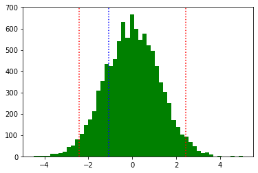

```python
np.random.seed(2004)
confidence = 95

data = pd.concat([score_v, score_c], ignore_index = True)
n_iter = 10000
perm_diffs = []
for i in range(n_iter):
    concat_permuted = data.sample(frac = 1, replace = False).reset_index(drop = True)
    perm_diff = concat_permuted[:len(score_v)].mean() - concat_permuted[len(score_v):].mean()
    perm_diffs.append(perm_diff)

b_crit = score_v.mean() - score_c.mean()
b_left = np.percentile(perm_diffs, (100 - confidence) / 2)
b_right = np.percentile(perm_diffs, (100 + confidence) / 2)
plt.hist(perm_diffs, bins = 50, color = "green")
plt.axvline(x = b_crit, color = "blue", linestyle = ":")
plt.axvline(x = b_left, color = "red", linestyle = ":")
plt.axvline(x = b_right, color = "red", linestyle = ":")
round(b_left, 3), round(b_crit, 3), round(b_right, 3)
```

**Вывод: Критическое значение входит в область, следовательно, нет оснований отвергать Н0**

Задача 5. Пункт (а)

```python
import warnings
warnings.filterwarnings('ignore')
## сформируем таблицу:
median = df["Балл"].median()
v_less_median = (df_v["Балл"] < median).sum()
c_less_median = (df_c["Балл"] < median).sum()
v_more_median = len(df_v) - v_less_median
c_more_median = len(df_c) - c_less_median
table = pd.DataFrame()
columns = ["less", "more"]
table = pd.DataFrame(columns = columns)
table.at["гласная", "less"] = v_less_median
table.at["согласная", "less"] = c_less_median
table.at["гласная", "more"] = v_more_median
table.at["согласная", "more"] = c_more_median
table
```

|  | less | more |
| --- | --- | --- |
| гласная | 28 | 21 |
| согласная | 138 | 145 |

```python
import math
from scipy.stats import norm
## 95% асимптотический интервал для отношения шансов хорошо написать экзамен (гласных к согласным)
OR = (21/28)/(145/138)
se = math.sqrt(1/28 + 1/21 + 1/138 + 1/145)
l = math.exp(math.log(OR) - 1.96 * se)
u = math.exp(math.log(OR) + 1.96 * se)
obs = (math.log(21/28) - math.log(145/138))/se
le = norm.cdf(obs)
ri = 1 - norm.cdf(obs)
p_value = 2 * min(le, ri)
p_value, (l, u)
```

```
(0.280180274566451, (0.3870902431823096, 1.3162320763800788))
```

P-value больше уровня значимости, следовательно, нет оснований отвергать нулевую гипотезу.

Задача 5. Пункт (б)

```python
import math
from scipy.stats import norm
## 95% асимптотический интервал для отношения шансов хорошо написать экзамен (гласных к согласным)
PR = (21/49)/(145/283)
se = math.sqrt(1/145 + 1/21 - 1/283 - 1/49)
l = math.exp(math.log(PR) - 1.96 * se)
u = math.exp(math.log(PR) + 1.96 * se)
obs = (math.log(21/49) - math.log(145/283))/se
le = norm.cdf(obs)
ri = 1 - norm.cdf(obs)
p_value = 2 * min(le, ri)
p_value, (l, u)
```

```
(0.3070947928050546, (0.5937492173912554, 1.1783661158504992))
```

P-value больше уровня значимости, следовательно, нет оснований отвергать нулевую гипотезу

Задача 5. Пункт (в)

```python
np.random.seed(2004)
n_iter = 10000
obs = (21/28)/(145/138)
bootstrap = []
for i in range(n_iter):
    bootstrap_v = np.random.choice(df_v["Балл"], size = 49)
    bootstrap_c = np.random.choice(df_c["Балл"], size = 283)
    bootstrap_v_more = np.sum(bootstrap_v > median)
    bootstrap_v_less = 49 - bootstrap_v_more
    bootstrap_c_more = np.sum(bootstrap_c > median)
    bootstrap_c_less = 283 - bootstrap_c_more
    OR = (bootstrap_v_more/bootstrap_v_less)/(bootstrap_c_more/bootstrap_c_less)
    bootstrap.append(OR)

li = 0
for i in range(n_iter):
    if bootstrap[i] > obs:
        li += (1)
    else:
        continue
ri = 0
for i in range(n_iter):
    if bootstrap[i] < obs:
        ri += (1)
    else:
        continue
p_value = 2 * min(li, ri)/n_iter
p_value
```

```
0.9822
```

Вывод: p-value больше уровня значимости, следовательно, нет оснований отвергать нулевую гипотезу

Задача 6. Пункт (а)

```python
df.head() ## исходный датафрейм
```

|  | Фамилия | Балл |
| --- | --- | --- |
| 0 | Репенкова | 16.0 |
| 1 | Ролдугина | 0.0 |
| 2 | Сафина | 19.0 |
| 3 | Сидоров | 26.0 |
| 4 | Солоухин | 21.0 |

```python
## создадим новый признак:
df["Длина"] = df["Фамилия"].apply(lambda x: len(x))
df.head()
```

|  | Фамилия | Балл | Длина |
| --- | --- | --- | --- |
| 0 | Репенкова | 16.0 | 9 |
| 1 | Ролдугина | 0.0 | 9 |
| 2 | Сафина | 19.0 | 6 |
| 3 | Сидоров | 26.0 | 7 |
| 4 | Солоухин | 21.0 | 8 |

$$ \mathbb{E}(Y_i) = \beta \times F_i$$$$ \mathbb{E}(Y_i) = \beta \times \mathbb{E}(F_i) $$$$ \bar Y_i = \beta \times \bar F_i $$$$ \beta_{MM} = \frac{\bar Y_i}{\bar F_i} $$

```python
beta = df["Балл"].mean()/df["Длина"].mean()
round(beta, 3) ## оценка beta методом моментов
```

```
2.061
```

```python
corr = df["Балл"].corr(df["Длина"])
round(corr, 3)
```

```
0.025
```

$$Ответ: \ \beta_{MM} = 2.061, \ \hat {corr} = 0.025 $$

Задача 6. Пункт (б)

```
0.643
```

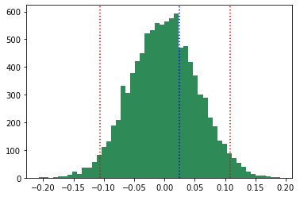

```python
np.random.seed(2004)
n_iter = 10000
confidence = 95

corrs = []
for i in range(n_iter):
    b_perm = np.random.permutation(df["Балл"])
    corr = np.corrcoef(b_perm, df["Длина"])[0, 1]
    corrs.append(corr)
plt.hist(corrs, bins = 50, color = "seagreen")
b_left = np.percentile(corrs, (100 - confidence)/2)
b_right = np.percentile(corrs, (100 + confidence)/2)

plt.axvline(x = 0.025, color = "blue", linestyle = ":")
plt.axvline(x = b_left, color = "red", linestyle = ":")
plt.axvline(x = b_right, color = "red", linestyle = ":")

li = 0
for i in range(n_iter):
    if corrs[i] > 0.025:
        li += (1)
    else:
        continue
ri = 0
for i in range(n_iter):
    if corrs[i] < 0.025:
        ri += (1)
    else:
        continue
p_value = 2 * min(li, ri)/n_iter
round(p_value, 3)
```

Вывод: p-value равен 0.643 (> 0.05), следовательно, нет оснований отвергать нулевую гипотезу

Задача 7. Диалог с ChatGPT. Задача №2 из контрольной работы №1 2021-2022 для базового потока.

**Я**: Вася играет в следующую игру. В урне пять белых и пять черных шаров. Из урны наудачу извлекают два шара. Если извлеченные шары оказались одного цвета, то Вася получает 10000 руб., а если — разных цветов, то теряет 10000 рублей. Найдите математическое Васиного выигрыша

**ChatGPT**: Для определения математического ожидания (выигрыша) Васи в этой игре, нужно учесть вероятности каждого возможного исхода.

Исходы, при которых Вася получает выигрыш:

Извлекается 2 белых шара. Вероятность этого исхода: (5/10) *(4/9) = 2/9. Извлекается 2 черных шара. Вероятность этого исхода: (5/10)* (4/9) = 2/9. Исходы, при которых Вася теряет деньги:

Извлекается 1 белый и 1 черный шар. Вероятность этого исхода: 1 - (2/9 + 2/9) = 5/9. Теперь можно рассчитать математическое ожидание (выигрыш) Васи: Выигрыш при извлечении 2 одноцветных шаров: 10000 *(2/9) = 2000 руб. Потеря при извлечении 2 разноцветных шаров: -10000* (5/9) = -5555.56 руб.

Математическое ожидание (выигрыш) Васи: 2000 - 5555.56 = -3555.56 руб.

Таким образом, математическое ожидание Васиного выигрыша в этой игре составляет -3555.56 рублей. Это означает, что в среднем Вася теряет деньги, играя в эту игру.

**Я**: Ты неверно решил задачу. А точнее, ты допустил ошибку в расчёте математического ожидания выигрыша при извлечении двух одноцветных шаров.

**Chat GPT**: Извините за путаницу. Давайте пересчитаем математическое ожидание Васиного выигрыша, учтя правильные вероятности.

Исходы, при которых Вася получает выигрыш:

Извлекается 2 белых шара. Вероятность этого исхода: (5/10) *(4/9) = 20/90. Извлекается 2 черных шара. Вероятность этого исхода: (5/10)* (4/9) = 20/90. Исходы, при которых Вася теряет деньги:

Извлекается 1 белый и 1 черный шар. Вероятность этого исхода: 1 - (20/90 + 20/90) = 50/90. Теперь пересчитаем математическое ожидание (выигрыш) Васи: Выигрыш при извлечении 2 одноцветных шаров: 10000 *(20/90) = 2222.22 руб. Потеря при извлечении 2 разноцветных шаров: -10000* (50/90) = -5555.56 руб.

Математическое ожидание (выигрыш) Васи: 2222.22 - 5555.56 = -3333.34 руб.

Таким образом, правильное математическое ожидание Васиного выигрыша в этой игре составляет -3333.34 рублей. Это означает, что в среднем Вася теряет деньги, играя в эту игру.

**Я**: Нет, снова неверный расчёт. Выигрыш при извлечении 2 одноцветных шаров будет равен 10.000 * 4/9 = 4444.44 руб. Переделай решение.

**Chat GPT**: Приношу извинения за предыдущие ошибки. Давайте пересчитаем математическое ожидание Васиного выигрыша, учитывая правильные вероятности.

Исходы, при которых Вася получает выигрыш:

Извлекается 2 белых шара. Вероятность этого исхода: (5/10) *(4/9) = 20/90. Извлекается 2 черных шара. Вероятность этого исхода: (5/10)* (4/9) = 20/90. Исходы, при которых Вася теряет деньги:

Извлекается 1 белый и 1 черный шар. Вероятность этого исхода: 1 - (20/90 + 20/90) = 50/90. Теперь пересчитаем математическое ожидание (выигрыш) Васи: Выигрыш при извлечении 2 одноцветных шаров: 10000 *(20/90) = 4444.44 руб. Потеря при извлечении 2 разноцветных шаров: -10000* (50/90) = -5555.56 руб.

Математическое ожидание (выигрыш) Васи: 4444.44 - 5555.56 = -1111.12 руб.

Таким образом, правильное математическое ожидание Васиного выигрыша в этой игре составляет -1111.12 рублей. Это означает, что в среднем Вася теряет деньги, играя в эту игру. **[это правильное решение]**

**Я**: Красавчик.

**Chat GPT**: Спасибо! Если у вас есть еще вопросы или нужна помощь, я всегда готов помочь.

Задача 8. Полезные источники

1. Курс по теории вероятности для ПМИ ФКН (пилотный поток): конспекты лекций для подготовки к минимумам. Также были полезны записи некоторых семинаров.

Ссылка: https://www.dropbox.com/s/8qrxp48zozhdpev/Shabanov-Probability-Theory_lectures_remastered.pdf?dl=0

1. Курс по математической статистике для ПМИ ФКН (пилотный поток): конспекты лекций для подготовки к минимумам.

Ссылка: https://www.overleaf.com/project/5cb0d36f2551f94e8f0ad210

1. Иногда пользовался материалами с курса теории вероятности НГУ (также для теории).

Ссылка: http://tvims.nsu.ru/courses.html

1. Помог курс по анализу данных на Python. Некоторые темы мы там разбирали раньше, чем на ТВиМС.

Ссылка: https://github.com/hse-econ-data-science/andan_2023

1. Моментами помогали подобные видео от Бориса Борисовича:

Ссылка: https://www.youtube.com/watch?v=XtHpXd46gFg